# BI-2019 Statistics Project №1

# 1 Объявление пакетов

```r
if(!require(purrr)) install.packages("purrr",repos = "http://cran.us.r-project.org")
if(!require(broom)) install.packages("broom",repos = "http://cran.us.r-project.org")
if(!require(tidyr)) install.packages("tidyr",repos = "http://cran.us.r-project.org")
```

```r
library(ggplot2)
library(purrr)
library(tidyr)
library(dplyr)
library(broom)
library(knitr)
```

# 2 Считывание данных

Не забудьте передать функции путь до папки с нашими данными.

```r
all_data = function(path){
  filenames = list.files(path = path, full.names = TRUE)
  df = lapply(filenames,
                    function(x){read.csv(file = x)})
  Reduce(function(x,y) {merge(x, y, all = TRUE)}, df)
}
whole_data <- all_data('~/Git_Repositories/BI_2019_Stats/Stat_project_1/Data')
```

# 3 Первый взгляд на данные

Для начала, взглянем на структуру данных:

```r
str(whole_data)
```

```
## 'data.frame':    4177 obs. of  9 variables:
##  $ Rings                                 : chr  "1" "10" "10" "10" ...
##  $ Sex..1...male..2...female..3...uvenil.: chr  "3" "1" "1" "1" ...
##  $ Length                                : chr  "0.075" "0.29" "0.33" "0.33" ...
##  $ Diameter                              : num  0.055 0.225 0.235 0.25 0.265 0.275 0.255 0.265 0.255 0.26 ...
##  $ Height                                : num  0.01 0.08 0.09 0.09 0.085 0.09 0.08 0.09 0.065 0.09 ...
##  $ Whole_weight                          : num  0.002 0.13 0.163 0.197 0.183 ...
##  $ Shucked_weight                        : num  0.001 0.0535 0.0615 0.085 0.077 0.0725 0.06 0.0615 0.0705 0.0725 ...
##  $ Viscera_weight                        : num  0.0005 0.026 0.034 0.041 0.046 0.043 0.0425 0.037 0.0385 0.056 ...
##  $ Shell_weight                          : num  0.0015 0.045 0.055 0.0605 0.065 0.07 0.054 0.0485 0.06 0.06 ...
```

Обратим внимание на то, что две переменные, которые должны быть числового типа, являются здесь факторными. Посмотрим на все градации факторов и попробуем, таким образом, найти что-то странное:

```r
unique(whole_data$Rings)
```

```
##  [1] "1"    "10"   "11"   "12"   "13"   "14"   "15"   "16"   "17"   "18"
## [11] "19"   "2"    "20"   "21"   "22"   "23"   "24"   "25"   "26"   "27"
## [21] "29"   "3"    "4"    "5"    "6"    "7"    "8"    "9"    "nine"
```

```r
unique(whole_data$Length)
```

```
##   [1] "0.075"                            "0.29"
##   [3] "0.33"                             "0.34"
##   [5] "0.345"                            "0.35"
##   [7] "0.36"                             "0.37"
##   [9] "0.375"                            "0.4"
##  [11] "0.415"                            "0.425"
##  [13] "0.43"                             "0.44"
##  [15] "0.445"                            "0.45"
##  [17] "0.46"                             "0.465"
##  [19] "0.47"                             "0.475"
##  [21] "0.485"                            "0.49"
##  [23] "0.495"                            "0.5"
##  [25] "0.505"                            "0.51"
##  [27] "0.515"                            "0.52"
##  [29] "0.525"                            "0.53"
```

[output cut: 53 more lines]

```r
unique(whole_data$Sex..1...male..2...female..3...uvenil.)
```

```
## [1] "3"     "1"     "2"     NA      "male"  "three" "one"
```

Ого. Мы и впрямь кое-что обнаружили - в переменной Rings кто-то написал nine вместо 9. В переменной length кто-то вместо NA оставил нам весьма печальное сообщение. А в уже действительно факторной переменной, отвечающей за пол, мы нашли довольно странное внесение факторных данных в датасет (“male” “three” “one”).

Исправим найденные нами ошибки:

```r
whole_data$Rings[which(whole_data$Rings == 'nine')] <- 9
whole_data$Sex..1...male..2...female..3...uvenil.[which(whole_data$Sex..1...male..2...female..3...uvenil. == 'male')] <- 1
whole_data$Sex..1...male..2...female..3...uvenil.[which(whole_data$Sex..1...male..2...female..3...uvenil. == 'three')] <- 3
whole_data$Sex..1...male..2...female..3...uvenil.[which(whole_data$Sex..1...male..2...female..3...uvenil. == 'one')] <- 1
```

Ошибку в length исправим переводом данных в numeric - печальное сообщение автоматически превратится в нужный нам NA:

```r
whole_data$Length <- as.numeric(whole_data$Length)
```

Rings переводить в numeric не будем - пребывание этой переменной в состоянии фактора нам ещё пригодится по ходу анализа.

А теперь взглянем на наличие NA:

```r
apply(whole_data, MARGIN = 2, function(x) sum(is.na(x)))
```

```
##                                  Rings
##                                      0
## Sex..1...male..2...female..3...uvenil.
##                                      1
##                                 Length
##                                      7
##                               Diameter
##                                      5
##                                 Height
##                                      2
##                           Whole_weight
##                                      1
##                         Shucked_weight
##                                      3
##                         Viscera_weight
##                                      0
##                           Shell_weight
##                                      2
```

Сначала разберёмся с пропусками в графе “пол”. Пропуск всего лишь один. Наблюдений относительно много. Потому в данном конкретном случае мы очень вряд ли ухудшим из-за этого результаты нашего анализа:

```r
whole_data <- whole_data[!is.na(whole_data$Sex..1...male..2...female..3...uvenil.), ]
```

Помимо удаления пропуска, в иных случаях можно было бы воспоьзоваться методами машинного обучения - например, логистической регрессией.

Кроме того, имеем море пропущенных переменных числовых. Заменим их на что-нибудь. Но на что? Бегло взглянем на наличие выбросов среди данных с помощью вот такого вот скаттерплота на все переменные:

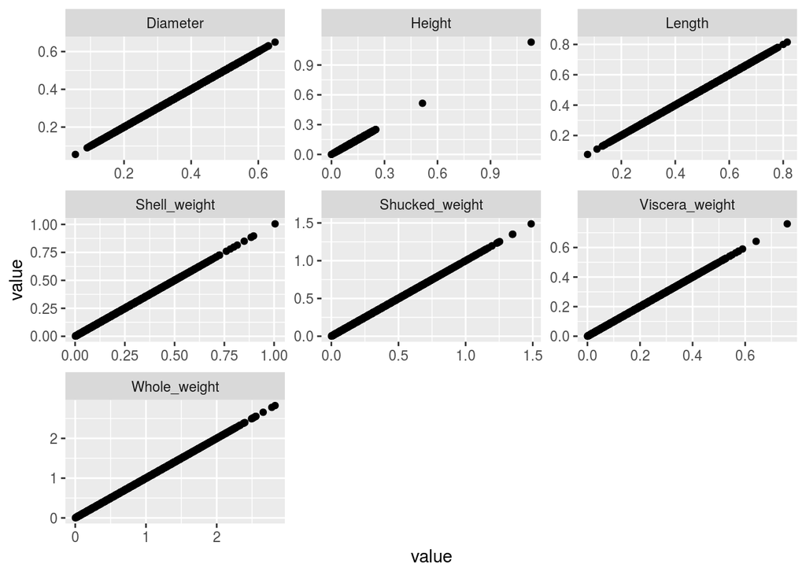

```r
whole_data %>%
  keep(is.numeric) %>%
  gather() %>%
  ggplot(aes(value, value)) +
  facet_wrap(~ key, scales = "free") +
  geom_point()
```

Увидим, что в некоторых переменных есть довольно ощутимые выбросы, которые довольно серьёзно могут исказть среднее. Потому лучшим решением для замены переменной изберём медиану. Заменим же все NA на медианы:

```r
for(i in 1:ncol(whole_data)){
  whole_data[is.na(whole_data[,i]), i] <- median(whole_data[,i], na.rm = TRUE)
}
```

Теперь взглянем на summary:

```r
summary(whole_data)
```

```
##     Rings           Sex..1...male..2...female..3...uvenil.
##  Length:4176        Length:4176
##  Class :character   Class :character
##  Mode  :character   Mode  :character
##
##
##
##      Length          Diameter         Height        Whole_weight
##  Min.   :0.0750   Min.   :0.055   Min.   :0.0000   Min.   :0.0020
##  1st Qu.:0.4500   1st Qu.:0.350   1st Qu.:0.1150   1st Qu.:0.4415
##  Median :0.5450   Median :0.425   Median :0.1400   Median :0.7995
##  Mean   :0.5241   Mean   :0.408   Mean   :0.1395   Mean   :0.8285
##  3rd Qu.:0.6150   3rd Qu.:0.480   3rd Qu.:0.1650   3rd Qu.:1.1530
##  Max.   :0.8150   Max.   :0.650   Max.   :1.1300   Max.   :2.8255
##  Shucked_weight   Viscera_weight     Shell_weight
##  Min.   :0.0010   Min.   :0.00050   Min.   :0.0015
##  1st Qu.:0.1865   1st Qu.:0.09337   1st Qu.:0.1300
##  Median :0.3360   Median :0.17075   Median :0.2335
##  Mean   :0.3595   Mean   :0.18058   Mean   :0.2388
##  3rd Qu.:0.5020   3rd Qu.:0.25300   3rd Qu.:0.3285
##  Max.   :1.4880   Max.   :0.76000   Max.   :1.0050
```

Помимо этого, мы могли бы воспользоваться предсказанеим пропущенных значений с помощью линейной регрессии, но их не настолько много, чтобы заморачиваться этим.